# EB Statistics Practicals Guideline - Practical 3

author: Francoise Cabada-Blanco

Last updated: 19/03/2022

In this third computer lab, you will learn how to use R test hypotheses about differences among more than two groups. Specifically, you will learn how to perform the following:

**1.** Create a dataframe from a csv file using the console

**2.** Plot a Q-Q plot to explore the distribution of the data and test for normality and homogeneity of variances

**3.** Conduct a one-way ANOVA

**4.** Conduct multiple comparisons

**5.** Conduct a two-way ANOVA

**6.** Conduct a Kruskall-Wallis test

The activities are presented in steps. For each step you are expected to answer one or two questions. Open the Answers word file to write your answers and copy your plots.

The code to perform all calculations is provided below. Read carefully the instructions and remember to run each line of code one by one in sequential order.

Remember that the first thing you need to do is check that your working directory is where you intend it to be. That would be on your **Practical 3** subfolder. You can check this by seeing if the files on the **Files** tab in RStudio are the ones in your **Practical 3** folder. If they are not, you can change the working directory by clicking in *Session* at the top menu, then *Set working directory* and lastly, *Choose directory*. This will prompt a window where you can Browse to the correct **Practical 3** folder.

## **STEP 1**

### Create a dataframe from a csv file using the console and describe your data

In environmental monitoring programmes one of the most frequently used sampling designs are those in which replicate samples are taken at set distances from what is believed to be a source of pollution; starting near that source and ending far from it. These are known as gradient sampling designs and allow not only to assess if the source is polluting its surrounding environment, but also to have an idea of the area influenced by the pollution.

In a long-term monitoring of an inshore oil platform in Maracaibo Lake, a big estuary in South America, the organisation in charge of the monitoring programme uses a gradient design, taking 15 water samples at three different distances from the platform: 20 m (near), 50 m (middle) and 150 m (far) -see Fig.1 below for reference- and determining the concentration of polycyclic aromatic hydrocarbons (PAH) in mg/L.

The organisation hires you to answer this question: Does the concentration of PAH in water varies with distance to the oil platform?

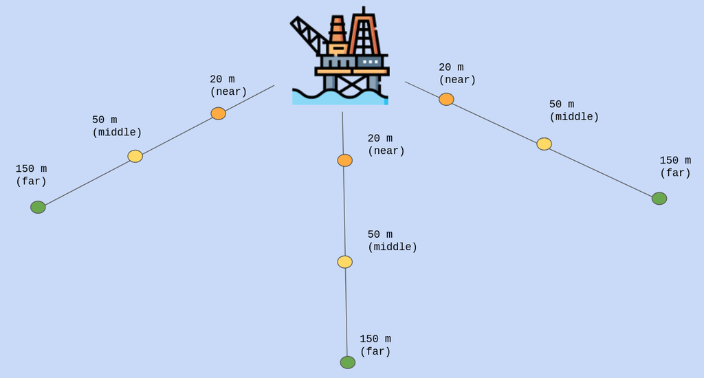

Figure 1. Illustration of a gradient sample design

The data is stored on a comma separated value file named pah.csv within the **Practical 3** subfolder. Open the file using the code below

```r
##############  Open a csv file from the console ###################

# open the file in a object named "hg"
pah<-read.csv("pah.csv", header = TRUE, stringsAsFactors = TRUE)

# inspect the type of object
class(pah)
```

> **Question 1**: How many cases and how many variables does the dataset has?

> **Question 1.1** : Specify the type of variable and the scale of measurement for each, indicating which one is the explanatory or independent variable and which is the response or dependent variable

> **Question 1.2** : Which one is the factor and how many levels does it has?

### Descriptive statistics

The first thing you need to do is summarise and describe your data. Here your main goal is to see if the concentration of PAH varies among the sampling distances. For that you need to first determine the maximum and minimum values of your response variable as a whole and then estimate the mean and standard deviation on each distance. You should also inlcude a table with summary statistics. The code below will help you to calculate all these.

```r
##############  Summary stats ###################

# we will use a new package called tydiverse that is brilliant for summarising
# install the package
install.packages("tidyverse")

# load the package from the library
library(tidyverse)

# find the minimum and maximum
min(pah$pah_concentration)

max(pah$pah_concentration)

# the following code does all these actions:
sumaryPAH<- pah %>%                   # in the dataset named pah
  group_by(treatment) %>%             # groups by the distance or treatements
  summarize(meanPAH=mean(pah_concentration),  # estimates the mean
            sdPAH=sd(pah_concentration),      # the standard deviation
            medianPAH=median(pah_concentration), # the median
            iqrPAH=IQR(pah_concentration),        # the IQR
            minPAH=min(pah_concentration),        # the minimum value
            maxPAH=max(pah_concentration))        # the maximum value

# View the summary table
View(summaryPAH)
```

> **Question 1.3** : Describe the observed data

### The null hypothesis

As we have seen in the pre-recorded lectures and the Q&A drop-ins, the first step in hypothesis testing is defining the hypothesis we are going to test against.

> **Question 1.4**: Write the logical hypothesis and its null equivalent (logical null hypothesis) in an IF-THEN statement

> **Question 1.5**: Write the null statistical hypothesis

## **STEP 2**

### Data screening

To provide an answer to the research question you need to test whether there is a significant difference in the concentration of PAH among the distances to the oil platform and, if there is, then explore how they differ differ. The first part can be done with a One-way ANOVA (because you only have 1 factor) and the second part with multiple comparisons.

The ANOVA assumes that the data from all groups come from populations with normal distributions and that the variances are homogeneous. In this step you will test for both.

#### Testing for non-normality

First we test the null hypothesis that the data comes from a normal distribution. Remember that in the test for normality, the null hypothesis is counterintuitive and failing to accept it, means that there is strong evidence for non-normality.

> **Ho**: data comes from a population with normal distribution

> **Hi**: data does not come from a population with normal distribution

```r
################### Test for non-normality ######################

# use the Shapiro-Wilks test with the 20m group
shapiro.test(pah$pah_concentration[pah$treatment=="20m"])

# use the Shapiro-Wilks test with the 50m group
shapiro.test(pah$pah_concentration[pah$treatment=="50m"])

# use the Shapiro-Wilks test with the 150m group
shapiro.test(pah$pah_concentration[pah$treatment=="150m"])
```

If the p-value is greater than $\alpha$ we fail to reject **Ho**

```r
################### QQ-plots ######################

# specify that we want the plots together.Build an empty table
# to put the plots in. So, 1 row and 3 columns
par(mfrow=c(1,3))

# create Q-Q plot for the 20 m level
qqnorm(pah$pah_concentration[pah$treatment=="20m"],main="20m")
qqline(pah$pah_concentration[pah$treatment=="20m"])

# create Q-Q plot for the 50 m level
qqnorm(pah$pah_concentration[pah$treatment=="50m"],main="50m")
qqline(pah$pah_concentration[pah$treatment=="50m"])

# create Q-Q plot for the 150 m level
qqnorm(pah$pah_concentration[pah$treatment=="150m"],main="150m")
qqline(pah$pah_concentration[pah$treatment=="150m"])
```

> Copy and paste the plots in your answer file and remember to reference them in the narrative where you are describing the results for the normality test.

#### Testing for homogeneity of variances

The second assumption of most parametric statistical test, and many non-parametric ones, is that the variances of the groups are homogeneous. To find out if they are, you will perform a Bartlett test this time because we now the data is normally distributed and the Q-Q plots show a better fit than those from the last practical.

The null and alternative hypothesis for a Bartlett’s test are:

> **Ho**: the variances are homogeneous

> **Hi**: the variances are heterogeneous

Use the code below to perform a Bartlett test

```r
#################### Test for homoscesdasticity ####################

# run the Bartlett test
bartlett.test(pah_concentration ~ treatment, data= pah)
```

> **Question 2.2**: Are the variances homogeneous? Write your results in narrative form. Remember to include the value of the test statistic, degrees of freedom and the p-value.

#### Using transformations to deal with non-normality and heteroscedasticity

As explained in the pre-recorded lectures and Moodle books, you can transform your response variable to make your transformed data normally distributed and/or homoscedastic. With the code below you can transform the data and run the test again to see if the transformation helped.

```r
#################### transforming data  ####################

# create a new variable or column in the data that is the logarithm of the AAT activity
pah$log_trans<-log(pah$pah_concentration)

# run the Bartlett test
bartlett.test(log_trans ~ treatment, data= pah)
```

## **STEP 3**

### One-way ANOVA

Use the code below to perform a one-way ANOVA.

```r
#################### One-way ANOVA ####################
# run the ANOVA
ow_anova<-aov(formula= log_trans ~ treatment, data= pah)

# print the ANOVA table
summary(ow_anova)
```

> **Question 3.1**: Do you failed to accept or to reject your Null Hypothesis? Write the results of your one-way ANOVA in a narrative form and remember to include the value of the test statistic, degrees of freedom and p-value.

## **STEP 4**

### Multiple Comparisons

Now let’s run a post-hoc test (in this case a Tukey’s test) so see *where* the difference lies. This method is used when the sample size of the groups are equal, as in our case

```r
#################### Tukey's test  ####################

TukeyHSD(ow_anova)
```

We start with the Scheffe method, which is the more conservative

```r
#################### Scheffe test  ####################

# we need first to install the package that has the function for the test
install.packages("DescTools")

# load the package from the library
library(DescTools)

# run the test
ScheffeTest(ow_anova)
```

We will follow with the Bonferroni method. This is best used when you already have specific pair-wise comparisons you want to make according to your logical hypothesis. In our example, we want to know if the concentration of PAH differs between 20m and 50m and then between 50m and 150m.

```r
#################### Bonferroni adjusted t-test  ####################

pairwise.t.test(pah$log_trans, pah$treatment, p.adj='bonferroni')
```

### Kruskal-Wallis for non-parametric ANOVA

You now know how to perform a one-way ANOVA. However, to learn how to do a Kruskal-Wallis test, let us assume the concentration of PAH failed the test for normality.

Use the code below to learn how to do a non-parametric test for the null hypothesis of no differences between more than two groups.

```r
#################### Kruskal-Wallis  ####################

kruskal.test(formula = log_trans ~ treatment,
             data = pah)
```

The specific post-hoc test we’re going to use requires the dunn.test package. A Dunn’s test conducts multiple pair-wise comparisons to look for differences in the medians - so very well suited for a Kruskal-Wallis post-hoc test! Remember that conducting multiple comparisons increases our risk of error. The Dunn’s test adjusts the p-values to account for the error involved in conducting multiple tests using different methods - in the function argument, we will specify that we want to utilise the (commonly used) Bonferroni correction.

```r
# install the package to run the Dunn test
install.packages("dunn.test")

# Load package
library(dunn.test)

dunn.test(pah$log_trans, pah$treatment, method="bonferroni")
```

The Dunn test also yields similar results that its parametric analogue post-hoc tests. The results from the Dunn test are reported as you did the pair-wise parametric tests, remembering to convert back the differences.

> **Question 4.2**: Why did we use the log-transformed PAH concentration if we are using non-parametric tests?

## **STEP 5**

### Two-way ANOVA

The organisation running the monitoring programme, forgot to send you additional data. They in fact took samples from water, but also sediment and want you to help them answer if *The pollution from the oil platform is worst in the sediment or the water column and does this depend on the distance to the platform?*

> **Question 5.1**: How many independent or explanatory variables do you have now? Identify the factors and their levels

For this type of data, in which you have two categorical explanatory or independent variables, that is, two factors, your statistical hypothesis is concerned with the interaction between those factors. And this type of hypothesis is tested with a two-way ANOVA. Use the code below to conduct the test.

Start by opening the new dataset from the file named pah_2way.csv

```r
################################ Open a csv file ############################
# open the file
pahAll<-read.csv(file="pah_2way.csv",header = TRUE, stringsAsFactors = TRUE)

#visualise the dataset
view(pahAll)
```

For the two-way ANOVA, we still use the aov() function, but this time we alter the formula to consider a potential interaction between two explanatory variables. For the sake of time, let us assume the data is normally distributed and homogeneous and we do not need to trasnform it.

```r
################################ Two-Way ANOVA ############################
# run the test
tw_anova <- aov(pah_concentration ~ distance * location,
                     data = pahAll)
# print the table
summary(tw_anova)
```

It would be useful to know a bit more about the nature of these variables and their interaction, so let’s make an interaction plot to help visualise the relationship:

```r
################################ Interaction plots ############################

dst <- factor(pahAll$distance)
loc <- factor(pahAll$location)
interaction.plot(dst,loc, pahAll$pah_concentration,
                 xlab = "Location",
                 ylab = "PAH concentraion",
                 main = "Interaction Plot")
```

[output not shown]